# Eksamensspørgsmål 3: Bayesianske netværk

## Opgave 1

Givet de to orienterede grafer:

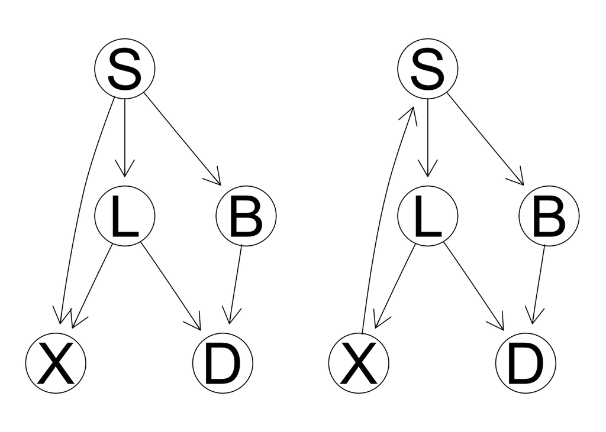

vil vi vide om de er acykliske. For nemmere at kunne regne på dem, repræsenteres de som matricer:

```
##   S L X B D
## S 0 1 1 1 0
## L 0 0 1 0 1
## X 0 0 0 0 0
## B 0 0 0 0 1
## D 0 0 0 0 0
```

```
##   S X L B D
## S 0 0 1 1 0
## X 1 0 0 0 0
## L 0 1 0 0 1
## B 0 0 0 0 1
## D 0 0 0 0 0
```

Hver række repræsenterer en knude, i indgangene er der et 1-tal hvor der er en orienteret graf til den i søjlen benævnte knude.

# Opgave 1.1: Lav en elgoritme, som kan afgøre om en DAG er acyklisk

Tanken i algoritmen er at så på “barnløse børn” eller “dead ends”. Algoritmen finder en dead end og fjerner den så fra DAG’en, det fortsætter den med indtil der ikke er flere knuder i grafen. Hvis der på et tidspunkt skulle være knuder tilbage, men ikke flere dead ends at fjerne, konkluderes det at grafen ikke er acyklisk.

```r
algoritme <- function(x){
  while(length(x)>1){
    sum = rowSums(x)
    if(any(sum==0)==TRUE){
      for(i in 1:nrow(x)){
        if(sum[i]==0){
          x <- x[-i,-i]
          break
        }
      }
    }else{
      break
    }
  }
  if(length(x)==1){
    print("Det er en DAG!")
    DAG<-TRUE
  }else{
    print("Det er ikke en DAG!")
    DAG<-FALSE
  }
  return(DAG)
}
```

# Opgave 1.2: Brug algoritmen i R

Vi undersøger nu den første graf.

```r
algoritme(graf1Matrix)
```

```
## [1] "Det er en DAG!"
```

```
## [1] TRUE
```

Og så den anden.

```r
algoritme(graf2Matrix)
```

```
## [1] "Det er ikke en DAG!"
```

```
## [1] FALSE
```

## Opgave 2

Vi har grafen:

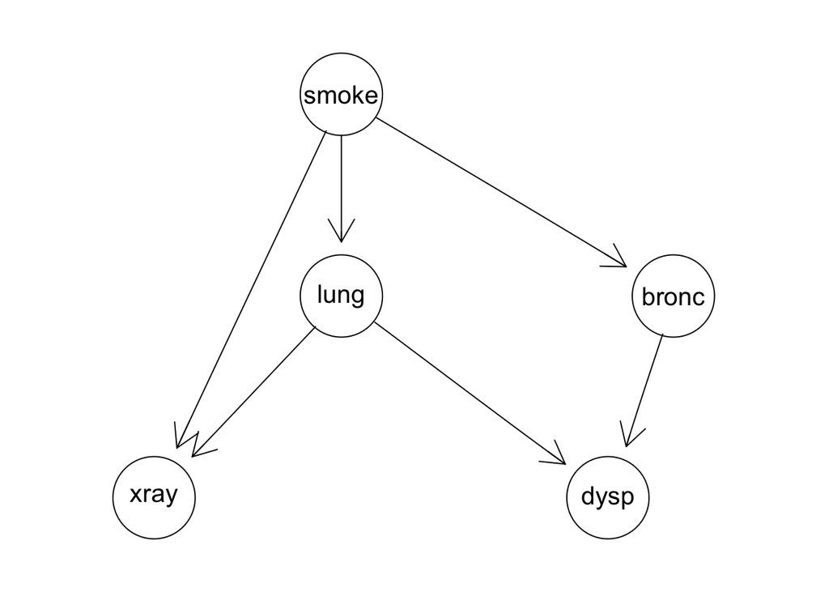

Og et udsnit af datasættet chestsim1000, som er simulerede patienter, som kunne have besøgt en torso klinik. Vi ønsker nu at løse de stillede opgaver

# Opgave 2.1 fra CPT’er til Bayisiansk netværk

Først definerer vi hvilke betingede sandsynligheder hele netværket kan deles op i ud fra den givne DAG, dette kunne også have være gjort den anden vej, altså ud fra dataen ved brug af ciTest. Først tæller vi hvor mange patienter der har henholdsvis yes og no i de forskellige situationer.

```r
s <- xtabs(~smoke, chestSim1000)
l_s <- xtabs(~lung+smoke, chestSim1000)
x_ls <- xtabs(~xray+lung+smoke, chestSim1000)
b_s <- xtabs(~bronc+smoke, chestSim1000)
d_lb <- xtabs(~dysp+lung+bronc, chestSim1000)
```

Så normaliserer vi

```r
p.s <- arnormalize(s, "first")
p.l_s <- arnormalize(l_s, "first")
p.x_ls <- arnormalize(x_ls, "first")
p.b_s <- arnormalize(b_s, "first")
p.d_lb <- arnormalize(d_lb, "first")
```

Og laver til sidst netværket

```r
cpt.list1 <- compileCPT(list(p.s, p.l_s, p.x_ls, p.b_s,  p.d_lb))
BayNet1 <- grain(cpt.list1)
BayNet1
```

```
## Independence network: Compiled: FALSE Propagated: FALSE
##   Nodes: chr [1:5] "smoke" "lung" "xray" "bronc" "dysp"
```

Det hele kunne have være gjort i en kommando (næsten, der er vist mere end en kommando, men de er på en linje)

```r
BayNet2<-grain(compileCPT(extractCPT(chestSim1000,graf3,smooth = 0)))
BayNet2
```

```
## Independence network: Compiled: FALSE Propagated: FALSE
##   Nodes: chr [1:5] "smoke" "lung" "xray" "bronc" "dysp"
```

# Opgave 2.2 den betingede fordeling af smoke givet dysp

Vi finder den betingede fordeling af smoke givet dysp; P(smoke|dysp)

```r
querygrain(BayNet1, nodes=c("smoke","dysp"), type="conditional")
```

```
##      smoke
## dysp        yes        no
##   yes 0.6060848 0.3939152
##   no  0.3589553 0.6410447
```

# Opgave 2.3 betingede fordelinger af lung

Vi finder først den betingede fordeling af lung givet smoke

```r
querygrain(BayNet1, nodes=c("lung","smoke"), type="conditional")
```

```
##      lung
## smoke        yes        no
##   yes 0.09892473 0.9010753
##   no  0.01308411 0.9869159
```

og så den betingede sandsynlighed af lung givet både smoke og bronc

```r
querygrain(BayNet1, nodes=c("lung","smoke", "bronc"), type="conditional")
```

```
## , , lung = yes
##
##      bronc
## smoke        yes         no
##   yes 0.09892473 0.09892473
##   no  0.01308411 0.01308411
##
## , , lung = no
##
##      bronc
## smoke       yes        no
##   yes 0.9010753 0.9010753
##   no  0.9869159 0.9869159
```

Det ses at informationen om bronc ikke ændrer noget, altså er bronc og lung betingt uafhængige givet smoke. Det kan også bekræftes med en test.

```r
ciTest(xtabs(~smoke+lung+bronc+dysp+xray,data=chestSim1000),set=c("lung","bronc","smoke"))
```

```
## Testing lung _|_ bronc | smoke
## Statistic (DEV):    1.686 df: 2 p-value: 0.4303 method: CHISQ
```

p-værdien er langt over 0.05 hvilket antyder at de er betinget uafhængige.

# Opgave 2.4 flere betingede fordelinger af lung

Vi finder først den betingede fordeling af lung givet smoke og dysp

```r
querygrain(BayNet1, nodes=c("lung","smoke","dysp"), type="conditional")
```

```
## , , lung = yes
##
##      dysp
## smoke       yes          no
##   yes 0.1569096 0.025335106
##   no  0.0362556 0.002381807
##
## , , lung = no
##
##      dysp
## smoke       yes        no
##   yes 0.8430904 0.9746649
##   no  0.9637444 0.9976182
```

og så den betingede sandsynlighed af lung givet smoke, dysp og bronc

```r
querygrain(BayNet1, nodes=c("lung","smoke","dysp","bronc"), type="conditional")
```

```
## , , bronc = yes, lung = yes
##
##      dysp
## smoke        yes          no
##   yes 0.10791090 0.055662507
##   no  0.01439724 0.007067658
##
## , , bronc = no, lung = yes
##
##      dysp
## smoke       yes          no
##   yes 0.5119009 0.016192169
##   no  0.1124113 0.001983594
##
## , , bronc = yes, lung = no
##
##      dysp
## smoke       yes        no
##   yes 0.8920891 0.9443375
##   no  0.9856028 0.9929323
##
## , , bronc = no, lung = no
##
##      dysp
## smoke       yes        no
##   yes 0.4880991 0.9838078
##   no  0.8875887 0.9980164
```

Det ses at der er ændringer i fordelingerne, altså tilfører bronc information. Vi udfører igen en test for at bekræfte

```r
ciTest(xtabs(~smoke+lung+bronc+dysp+xray,data=chestSim1000),set=c("lung","bronc","dysp","smoke"))
```

```
## Testing lung _|_ bronc | dysp smoke
## Statistic (DEV):   36.807 df: 3 p-value: 0.0000 method: CHISQ
```

og det ses at der ikke er betinget uadhængighed.

# Opgave 2.5 messagepassing algoritme

Vi starter ovre i latexdokumentet, hvor der skitseres hvordan man kommer fra en DAG til et kliketræ. Der konkluderes at vi nu skal se på de tre funktioner q_1, q_2 og q_3, som indgår i P(V)=q_1(X,L,S)q_2(S,L,B)q_3(L,B,D)

Vi collecter evidence

```r
q3.LB=armarg(q3.LBD,c("lung","bronc"))
q3.LBD=ardiv(q3.LBD,q3.LB)
q2.SLB=armult(q2.SLB, q3.LB)

q2.SL=armarg(q2.SLB,c("smoke","lung"))
q2.SLB=ardiv(q2.SLB,q2.SL)
q1.XLS=armult(q1.XLS, q2.SL)
```

Vi distrubuter evidence

```r
q1.SL=armarg(q1.XLS,c("smoke","lung"))
q2.SLB=armult(q2.SLB,q1.SL)

q2.LB=armarg(q2.SLB,c("lung","bronc"))
q3.LBD=armult(q3.LBD,q2.LB)
```

Og så udregner vi klikemarginalerner

```r
p.XLS=q1.XLS;p.XLS
```

```
## , , xray = yes
##
##      lung
## smoke   yes    no
##   yes 0.046 0.021
##   no  0.007 0.021
##
## , , xray = no
##
##      lung
## smoke yes    no
##   yes   0 0.398
##   no    0 0.507
```

```r
p.SLB=q2.SLB;p.SLB
```

```
## , , bronc = yes
##
##      lung
## smoke         yes        no
##   yes 0.027303226 0.2486968
##   no  0.002093458 0.1579065
##
## , , bronc = no
##
##      lung
## smoke         yes        no
##   yes 0.018696774 0.1703032
##   no  0.004906542 0.3700935
```

```r
p.LBD=q3.LBD;p.LBD
```

```
## , , dysp = yes
##
##      bronc
## lung         yes         no
##   yes 0.02655184 0.02038468
##   no  0.33331432 0.04885505
##
## , , dysp = no
##
##      bronc
## lung         yes          no
##   yes 0.00284484 0.003218634
##   no  0.07328899 0.491541633
```